# Team

- **Tommaso Giordano**,
- **Guido Gonnella**,
- **Andrea Migliorini**,
- **Simone Oggioni**,
- **Luca Olivieri**.

**Video**: https://drive.google.com/file/d/1PacfOhmIsuAtYV4P8HEvrRlB0yHz85rb/view?usp=share_link

# 1.0 Pipelines

In this section, we are going to build two end-to-end pipelines:

1. A **pseudo-labeling** pipeline on the unlabeled dataset DQA-U.
2. A **RRR-then-answer** useful in a real-world scenario in which contexts are not inherently assigned to questions, but gathered in a corpus.

To simplify the process, we are going to consider the zero-shot prompt instead of the one-shot, which should actually be adopted for its better empirical performance.

## Pseudo-labeling Pipeline

In pseuod-labeling, a model fairly tuned is used to provide predicted labels on a dataset without annotated ones, and use them instead. Given the intrinsic uncertainty and noise of the process (prediction might not be correct but we have no way to know), only the predictions in which the model is quite confident of (that is, have probability higher than some given threshold) are used as pseudo-labels.

Probabilities, strictly speaking, are available only in probabilistic classifiers, which LLMs are not. However, we have a frequentist technique to produce them: we can raise the `temperature` (and other variance parameters, e.g., `top-k`, `top-p`, ...), generate an odd number of answers and compute the probabilities by normalising the number of class appearances by the total number of trials. This leverages the internal variance of the LLMs sampling process to produce some variability. Alternatively, we could also use `beam-search` and gather the beams.

This high-temperature, multi-sampling approach is analogous to the **self-consistency** technique, in which many answers are generated in the same way to self-ensemble the model and select the best answer by majority voting, to cut down variance and improve performance.

```python
model = "thewindmom/llama3-med42-8b"
```

```python
ollama.pull(model)
responses = []
```

To reach our goal, we have to adopt another prompt in which the model is asked to generate a final decision starting from the question and the long answer (the context is not required anymore since the long answer is already there).

```python
alpaca_pl_prompt = """Below is a question on a certain medical topic and a long answer which answers the question.

Your task is to provide the final decision regarding the question judging from the long answer. Provide the final decision between curly brackets, choosing among this options:
    - {{yes}}
    - {{no}}
    - {{maybe}}

### Question:
{}

### Long Answer:
{}

### Final Decision:
"""
```

However this prompt should be evaluated: if the model does not achieve a sufficiently good performance, its predictions will be mostly wrong and, hence, inappropriate for pseudo-labeling!

### Evaluation

```python
def formatting_prompts_pl_func(examples):
    questions       = examples["question"]
    contexts        = examples["context"]
    long_answers    = examples["long_answer"]
    final_decisions = examples["final_decision"]
    queries_pl = []
    for question, context, long_answer, final_decision in zip(questions, contexts, long_answers, final_decisions):
        user_text = alpaca_pl_prompt.format(question, long_answer)
        query_pl = [
            {"role": "system", "content": "You are a medical assistant. Please be thorough and provide an informative answer."},
            {"role": "user",    "content": user_text},
        ]
        queries_pl.append(query_pl)
    return {"query_pl": queries_pl}
```

```python
dataset_test = dataset_test.map(formatting_prompts_pl_func, batched = True)
```

```python
dataset_test["query_pl"][0]
```

```
[{'content': 'You are a medical assistant. Please be thorough and provide an informative answer.',
  'role': 'system'},
 {'content': 'Below is a question on a certain medical topic and a long answer which answers the question.\n\nYour task is to provide the final decision regarding the question judging from the long answer. Provide the final decision between curly brackets, choosing among this options:\n    - {yes}\n…
  'role': 'user'}]
```

```python
for i in range(3):
    print(f"Response n. {i+1}")
    response = chat(model=model, messages=dataset_test["query_pl"][i], options={"num_predict": 512})
    display(Markdown(response['message']['content']))
    display(Markdown("---"))
```

```
Response n. 1
```

{yes}

```
Response n. 2
```

{no}

```
Response n. 3
```

{maybe}

The long answer provided does not explicitly confirm that syncope during bathing in infants is a pediatric form of water-induced urticaria. It suggests "aquagenic maladies," which may include water-induced urticaria, but it doesn't specifically state the connection between syncope and aquagenic urticaria in infants. Therefore, based on the given information, the final decision would be {maybe}, indicating uncertainty about whether syncope during bathing in infants is a pediatric form of water-induced urticaria.

```python
for i, conversation in my_tqdm(dataset_test["query_pl"]):
    response = chat(model=model, messages=conversation, options={"num_predict": 1024, "num_ctx": 4096})
    responses.append(response)
```

```python
outs = [extract_final_decision(r["message"]["content"]) for r in responses]
```

```python
bad_idxs = [i for i, x in enumerate(outs) if x not in ["yes", "no", "maybe"]]
len(bad_idxs)
```

```
0
```

```python
label_enc = LabelEncoder()
label_enc.fit(classes)
preds = label_enc.transform([extract_final_decision(s) for i, s in enumerate(outs) if i not in bad_idxs])
targets = label_enc.transform([s for i, s in enumerate(dataset_test["final_decision"][:len(outs)]) if i not in bad_idxs])
```

```python
print(classification_report(targets, preds, target_names=label_enc.classes_, labels=range(len(classes))))
print(confusion_matrix(targets, preds))
```

```
              precision    recall  f1-score   support

       maybe       0.24      0.29      0.26        49
          no       0.83      0.86      0.84       145
         yes       0.85      0.80      0.83       222

    accuracy                           0.76       416
   macro avg       0.64      0.65      0.64       416
weighted avg       0.77      0.76      0.77       416

[[ 14  12  23]
 [ 13 124   8]
 [ 31  13 178]]
```

The model achieves an accuracy of **76%**, which is higher than our SoTA in reasoning-required setting. This is expected since, in this reasoning-free context, the LLM has an unfair advantage of knowing the long answer in advance. This would not happen in a real-world scenario!

### Prediction

Let's define our pipeline:

```python
def formatting_prompts_plu_func(examples):
    questions       = examples["question"]
    contexts        = examples["context"]
    long_answers    = examples["long_answer"]
    queries_pl = []
    for question, context, long_answer in zip(questions, contexts, long_answers):
        user_text = alpaca_pl_prompt.format(question, long_answer)
        query_pl = [
            {"role": "system", "content": "You are a medical assistant. Please be thorough and provide an informative answer."},
            {"role": "user",    "content": user_text},
        ]
        queries_pl.append(query_pl)
    return {"query_pl": queries_pl}
```

```python
dataset_unlabel = dfa_u.map(formatting_prompts_plu_func, batched = True).select(range(0, 500))
```

```python
dataset_unlabel["query_pl"][0]
```

```
[{'content': 'You are a medical assistant. Please be thorough and provide an informative answer.',
  'role': 'system'},
 {'content': 'Below is a question on a certain medical topic and a long answer which answers the question.\n\nYour task is to provide the final decision regarding the question judging from the long answer. Provide the final decision between curly brackets, choosing among this options:\n    - {yes}\n…
  'role': 'user'}]
```

Now, we set `temperature=1.0` (should be high enough), `n_trial=5` so that can compute discrete probabilities, and begin the pseudo-labeling process:

```python
n_trial = 5
ps_list = []

for i, conversation in my_tqdm(dataset_unlabel["query_pl"][::100]):
    trials = []
    for _ in range(n_trial):
        response = chat(model=model, messages=conversation,
                        options={
                            "num_predict": 1024,
                            "num_ctx": 4096,
                            "temperature": 1.0
                        })
        trial = extract_final_decision(response["message"]["content"])
        trials.append(trial)
    class_counts = Counter(trials)
    class_, count = class_counts.most_common(1)[0]
    ps_list.append((class_, count/n_trial))
```

Here is the most common class (along with its probability) for some samples:

```python
ps_list
```

```
[('yes', 0.6), ('maybe', 1.0), ('no', 1.0), ('maybe', 0.8), ('no', 1.0)]
```

Done! Right now, we can select the desired threshold (e.g. `thr=0.8`) and extract our pseudo-labels!

```python
list(filter(lambda x: x[1] >= 0.8, ps_list))
```

```
[('maybe', 1.0), ('no', 1.0), ('maybe', 0.8), ('no', 1.0)]
```

## RRR-Answer Pipeline

So far, answers were generated on top of contexts, and question from the dataset comes with its context. However, in real-world, production environments, the appropriate contextual context information is not immediately available, but has to be retrieved from a corpus of documents. These corpora has to store and index the vectorial representation of each document (typically computed with sentence/document embedder) for fast retrieval. Therefore, the retrieval and answering process comprises multiple stages that can be implemented in a RRR-Answer pipeline.

Therefore, the difference with the pipelines used so far is that the context is not given but is a degree-of-freedom of the answering process.

```python
model = "thewindmom/llama3-med42-8b"
```

```python
ollama.pull(model)
responses = []
```

We will leverage two very popular and easy to deploy sentence-transformers and cross-encoders: `multi-qa-MiniLM-L6-cos-v1` and `cross-encoder/ms-marco-MiniLM-L-6-v2`.

```python
bi_encoder = SentenceTransformer('multi-qa-MiniLM-L6-cos-v1')
cross_encoder = CrossEncoder('cross-encoder/ms-marco-MiniLM-L-6-v2')
```

Create a corpus by merging and undersampling contexts coming from all the datasets.

```python
corpus_text = [*dfa_l["context"], *dfa_a["context"], *dfa_u["context"]][:1000]
```

```python
ids = list(range(len(corpus_text)))
print("Step 1: Encoding corpus with bi‑encoder…")
corpus_embeddings = bi_encoder.encode(corpus_text, convert_to_tensor=False, show_progress_bar=True)
```

```
Step 1: Encoding corpus with bi‑encoder…
```

Semantic retrieval has to be fast, hence we create the index for the corpus:

```python
dim = corpus_embeddings.shape[1]
index = hnswlib.Index(space='cosine', dim=dim)
index_path = "pubmedqa_hnsw_contexts_index.bin"

if os.path.exists(index_path):
    print("Loading existing HNSW index from disk…")
    index.load_index(index_path)
    print("Done!")
else:
    print("Creating new HNSW index and adding items…")
    index.init_index(max_elements=len(corpus_embeddings), ef_construction=400, M=64)
    index.add_items(corpus_embeddings, ids)
    index.save_index(index_path)
    print(f"HNSW index saved to '{index_path}'.")
```

```
Creating new HNSW index and adding items…
HNSW index saved to 'pubmedqa_hnsw_contexts_index.bin'.
```

Let's test our pipeline on a 3 example questions from `dfa-l`:

```python
top_k = 5

sampled_idxs = random.sample(range(len(dfa_l)), 3)
```

```python
for i, query_i in enumerate(sampled_idxs):
    query = dfa_l["question"][query_i]

    # Sentence transformer retrieval
    query_emb = bi_encoder.encode(query, convert_to_tensor=False)
    candidate_ids, distances = index.knn_query(query_emb, k=top_k)
    hits = [corpus_text[idx].strip() for idx in candidate_ids[0]]

    # Cross-encoder re-ranking
    pairs = [(query, hits[j]) for j in range(top_k)]
    cross_scores = cross_encoder.predict(pairs)
    best = hits[cross_scores.argmax()]

    # Question answering
    conv = alpaca_user_prompt.format(query, best)

    answer = chat(model=model,
                    messages=[
                        {"role": "system", "content": "You are a medical assistant. Please be thorough and provide an informative answer."},
                        {"role": "user", "content": conv},
                    ],
                    options={"num_predict": 1024, "num_ctx": 4096}
    )["message"]["content"]

    display(Markdown(f"## QUESTION N. {i+1}"))
    display(Markdown(query))
    display(Markdown(f"### Best candidate context"))
    display(Markdown(best))
    display(Markdown(f"### Assistant Answer"))
    display(Markdown(answer))
```

QUESTION N. 1

Does the enteral feeding advancement affect short-term outcomes in very low birth weight infants?

Best candidate context

Controversy exists regarding the optimal enteral feeding regimen of very low birth weight infants (VLBW). Rapid advancement of enteral feeding has been associated with an increased rate of necrotizing enterocolitis. In contrast, delaying enteral feeding may have unfavorable effects on nutrition, growth, and neurodevelopment. The aim is to compare the short-term outcomes of VLBW infants in tertiary care centers according to their enteral feeding advancement. We prospectively studied the influence of center-specific enteral feeding advancement in 1430 VLBW infants recruited from 13 tertiary neonatal intensive care units in Germany on short-term outcome parameters. The centers were post hoc stratified to "rapid advancement to full enteral feeds" (median duration of advancement to full enteral feeds<or =12.5 days; 6 centers), that is, rapid advancement (RA), or "slow advancement to full enteral feeds" (median duration of advancement to full enteral feeds>12.5 days; 7 centers), that is, slow advancement (SA). VLBW infants born in centers with SA (n = 713) had a significantly higher rate of sepsis compared with VLBW infants born in centers with RA (n = 717), which was particularly evident for late-onset sepsis (14.0% vs 20.4%; P = 0.002). Furthermore, more central venous lines (48.6% vs 31.1%, P<0.001) and antibiotics (92.4% vs 77.7%, P<0.001) were used in centers with SA.

Assistant Answer

Based on the given context, it can be concluded that enteral feeding advancement does affect short-term outcomes in very low birth weight infants. The study analyzed the influence of center-specific enteral feeding advancement strategies (rapid advancement to full feeds versus slow advancement) in 1430 VLBW infants from 13 tertiary neonatal intensive care units in Germany on various short-term outcome parameters. The results showed that VLBW infants born in centers with slow advancement had a significantly higher rate of sepsis, particularly late-onset sepsis, as well as increased usage of central venous lines and antibiotics compared to those born in centers with rapid advancement.

Considering these findings, the answer would be: {yes}

QUESTION N. 2

Treadmill training post stroke: are there any secondary benefits?

Best candidate context

To explore the secondary benefits of treadmill training for people in the chronic stage of recovery from stroke. Modified random assignment, matched-pair control group design with repeated measures. Outpatient stroke centre. Twenty individuals post first stroke who acknowledged walking slower than pre stroke. Participants matched by side of hemiparesis and motor impairment. Twelve 20-minute sessions of walking on a treadmill or weekly phone call. Depression (Beck Depression Index), mobility and social participation (Stroke Impact Scale 3.0 subscales) were assessed initially, at the end of 12 treatments (four weeks) and six weeks later. No significant difference was found between groups for any dependent measure. The ANOVA to investigate main effects in each group found no significant findings in the control group; however in the treatment group significant improvements over time for depression (P = 0.005, P<0.001), mobility (P = 0.008) and social participation (P = 0.004) were demonstrated.

Assistant Answer

Based on the given context, treadmill training post-stroke does have secondary benefits. The study's results show significant improvements in depression, mobility, and social participation for participants who underwent treadmill training compared to those in the control group. There were no significant differences found between groups at the initial assessment or at the end of 12 treatments (four weeks), but the treatment group showed notable improvement over time for the mentioned parameters. Therefore, the final decision would be {yes}.

QUESTION N. 3

Is obesity a risk factor for wheezing among adolescents?

Best candidate context

To investigate the effect of obesity at the start of adolescence on the prevalence, incidence and maintenance of chest wheezing among individuals aged 11-15 years in a birth cohort in a developing country. The seventh follow-up of the 1993 Pelotas birth cohort occurred in 2004 (individuals aged 10-11 years). Between January and August 2008, the eighth follow-up of the cohort was conducted. All the individuals of the original cohort who were alive (who were then adolescents aged between 14 and 15 years) were targets for the study. The International Study of Asthma and Allergies in Childhood (ISAAC) questionnaire was used to define wheezing. In addition to the body mass index (BMI), used to define obesity by the World Health Organization (WHO) criteria, we assessed skinfold thickness. From the original cohort, 4,349 individuals were located (85.7% follow-up rate). The prevalence of chest wheezing at 11 and 15 years were 13.5% (95% CI: 12.5%-14.5%) and 12.1% (95% CI: 11.1%-13.1%), respectively. The prevalence of wheezing at both times was 4.5% (95% CI: 3.9%-5.1%) and the incidence of wheezing was 7.5% (95% CI: 6.7%-8.3%). Independent of the effect of various confounding variables, the prevalence of wheezing at 15 years was 50% greater among obese individuals than among eutrophic individuals at 11 years (RR 1.53; 95% CI: 1.14-2.05). The greater the skinfold tertile at 11 years, the higher the prevalence of wheezing at 15 years was (p = .011). Weight status and skinfolds did not present any association with incident wheezing. After controlling for confounding factors, the risk of persistent wheezing among obese individuals at 11 years was 1.82 (95% CI: 1.30-2.54).

Assistant Answer

Based on the given context and study findings, obesity can be considered a risk factor for wheezing among adolescents.

The study followed a birth cohort over time to investigate the relationship between obesity during early adolescence and chest wheezing in later adolescence (14-15 years old). It used the International Study of Asthma and Allergies in Childhood (ISAAC) questionnaire to define wheezing, as well as body mass index (BMI) to determine obesity by WHO criteria. The results indicated that independent of confounding variables, obese individuals at 11 years showed a 50% higher prevalence of wheezing compared to eutrophic individuals at the same age (RR 1.53; 95% CI: 1.14-2.05). Additionally, as skinfold thickness increased at 11 years, so did the prevalence of wheezing at 15 years (p = .011). Although weight status and skinfolds had no association with incident wheezing, obese adolescents at 11 years showed a higher risk for persistent wheezing by age 15 (RR 1.82; 95% CI: 1.30-2.54) after controlling for confounding factors.

Therefore, based on this study's findings and reasoning, the answer to the question is {yes}. Obesity can be identified as a risk factor for wheezing among adolescents due to its association with both prevalence and persistence of chest wheezing over time.

We can even submit our own question (or generate it with an LLM):

```python
gpt_question = chat(model=model,
                    messages=[{"role": "user", "content": "Give me a random yes/no question in a medical context."}],
                    options={"num_predict": 1024, "num_ctx": 4096})
gpt_question["message"]["content"]
```

```
'Is the antibiotic vancomycin considered a first-line treatment for methicillin-resistant Staphylococcus aureus (MRSA) infections?'
```

```python
top_k = 5

### Pose your question ###
query = gpt_question["message"]["content"]
### - - - - - - - - -  ###

query_emb = bi_encoder.encode(query, convert_to_tensor=False)
candidate_ids, distances = index.knn_query(query_emb, k=top_k)
hits = [corpus_text[idx].strip() for idx in candidate_ids[0]]

# Cross-encoder re-ranking
pairs = [(query, hits[j]) for j in range(top_k)]
cross_scores = cross_encoder.predict(pairs)
best = hits[cross_scores.argmax()]

conv = alpaca_user_prompt.format(query, best)

answer = chat(model=model,
                messages=[
                    {"role": "system", "content": "You are a medical assistant. Please be thorough and provide an informative answer."},
                    {"role": "user", "content": conv},
                ],
                options={"num_predict": 1024, "num_ctx": 4096}
)["message"]["content"]

display(Markdown(f"# OUR QUESTION"))
display(Markdown(query))
display(Markdown(f"### Best candidate context"))
display(Markdown(best))
display(Markdown(f"### Assistant Answer"))
display(Markdown(answer))
```

OUR QUESTION

Is the antibiotic vancomycin considered a first-line treatment for methicillin-resistant Staphylococcus aureus (MRSA) infections?

Best candidate context

Vancomycin is the primary treatment for infections caused by methicilin-resistant Staphylococcus aureus (MRSA). The association of vancomycin treatment failures with increased vancomycin minimum inhibitory concentration (MIC) is a well-recognized problem. A number of single-centre studies have identified progressive increases in glycopeptide MICs for S. aureus strains over recent years - a phenomenon known as vancomycin MIC creep. It is unknown if this is a worldwide phenomenon or if it is localized to specific centers. The aim of this study was to evaluate the trend of vancomycin MIC for isolates of MRSA over a 3-year period in a tertiary university hospital in Portugal. MRSA isolates from samples of patients admitted from January 2007 to December 2009 were assessed. Etest method was used to determine the respective vancomycin MIC. Only one isolate per patient was included in the final analysis. A total of 93 MRSA isolates were studied. The vancomycin MICs were 0.75, 1, 1.5 and 2 mg/L for 1 (1.1%), 19 (20.4%), 38 (40.9%), 35 (37.6%) isolates, respectively. During the 3 year period, we observed a significant fluctuation in the rate of MRSA with a vancomycin MIC > 1 mg/L (2007: 86.2%; 2008: 93.3%; 2009: 58.8%, p = 0.002). No MRSA isolate presented a MIC > 2 mg/L.

Assistant Answer

Based on the given context, vancomycin is considered the primary treatment for methicillin-resistant Staphylococcus aureus (MRSA) infections. The study cited discusses trends in vancomycin minimum inhibitory concentrations (MICs) for MRSA isolates over a three-year period, highlighting fluctuating rates of MRSA with MIC > 1 mg/L across these years. However, no isolate presented a MIC > 2 mg/L during this period, suggesting that it remains an effective first-line treatment for MRSA infections within the studied context.

Final decision: {yes}

The antibiotic vancomycin is considered a first-line treatment for methicillin-resistant Staphylococcus aureus (MRSA) infections based on the provided information.

# 2.0 Text-to-speech

```python
%%capture
!pip install numpy scipy librosa unidecode inflect

%matplotlib inline
import matplotlib
from matplotlib import pyplot as plt
import torch
from IPython.display import Audio
```

## Functions

Text-to-MEL has a limit on the length of the MEL spectrogram it can produce while maintaining good results.

To address this, we split the sentence to create shorter segments. We then run the Text-to-MEL process on each chunk individually and concatenate the resulting spectrograms.

We split the input text according to these rules:

1. Split at every period
2. If a segment is still too long, we further split it at every comma
3. If a segment is still too long, we further split it into chunks of n words.

```python
# First split sentence using periods. than if split is too long split again every n words
def split_text(text, n):
    # Step 1: Split by periods
    raw_sentences = [s.strip() for s in text.split('.') if s.strip()]
    chunks = []

    for sentence in raw_sentences:
        words = sentence.split()
        if len(words) <= n:
            chunks.append(' '.join(words))
        else:
            # Step 2: Try splitting by commas
            sub_sentences = [s.strip() for s in sentence.split(',') if s.strip()]
            for sub in sub_sentences:
                sub_words = sub.split()
                if len(sub_words) <= n:
                    chunks.append(' '.join(sub_words))
                else:
                    # Step 3: Split into n-word chunks
                    for i in range(0, len(sub_words), n):
                        chunk = ' '.join(sub_words[i:i+n])
                        chunks.append(chunk)

    return chunks

# Inference from text to mel and from mel to audio
def text_to_audio(text, utils, spectrogram_model, audio_model, words_split):
    text_chunks = split_text(text, words_split)
    mel_chunks = []

    with torch.no_grad():
        for chunk in text_chunks:
            sequences, lengths = utils.prepare_input_sequence([chunk])
            mel, _, _ = spectrogram_model.infer(sequences, lengths)
            mel_chunks.append(mel)

        # Concatenate all mels along the time axis
        unified_mel = torch.cat(mel_chunks, dim=2)
        audio = audio_model.infer(unified_mel)

    return audio, unified_mel

# Plot mel spectrogram
def plot_mel(mel):
  fig = plt.figure(figsize=(10,4))
  plt.pcolormesh(mel[0].cpu().numpy())
  plt.colorbar(label='Power [dB]')
  plt.ylabel('Frequency [Hz]')
  plt.xlabel('Time [10ms]')
  plt.show()

# Plot audio waveform
def plot_audio(audio):
  fig = plt.figure(figsize=(16,4))
  plt.plot(audio, linewidth=0.4)
  plt.ylabel('Amplitude')
  plt.xlabel('Samples')
  plt.show()

# Return audio
def play_audio(audio, rate):
  return Audio(audio, rate=rate)
```

## Load models

Load models:

- Tacotron produces a spectrogram from text
- Waveglow produces audio from spectrogram

```python
%%capture
# Import models

tacotron2 = torch.hub.load('NVIDIA/DeepLearningExamples:torchhub', 'nvidia_tacotron2', model_math='fp16') # text to spectrogram
tacotron2 = tacotron2.to('cuda')
tacotron2.eval()

waveglow = torch.hub.load('NVIDIA/DeepLearningExamples:torchhub', 'nvidia_waveglow', model_math='fp16') # spectrogram to audio
waveglow = waveglow.remove_weightnorm(waveglow)
waveglow = waveglow.to('cuda')
waveglow.eval()

utils = torch.hub.load('NVIDIA/DeepLearningExamples:torchhub', 'nvidia_tts_utils') # converts text into numeric sequence
```

## Inference

```python
# Inputs for audio generation: text and rate
text = "Trauma patients have a significant complication rate related to anticoagulation therapy, and predicting which patients will develop a complication remains unclear. Prospective studies are needed to determine which treatment regimen, if any, is appropriate to safely anticoagulate this high risk population."
rate = 22050

audio, mel = text_to_audio(text, utils, tacotron2, waveglow, words_split=20) # Generate audio from text
audio = audio[0].cpu().numpy() # Convert to numpy
```

```python
# Play audio file
play_audio(audio, rate)
```

[interactive chart not shown]

## Plot results

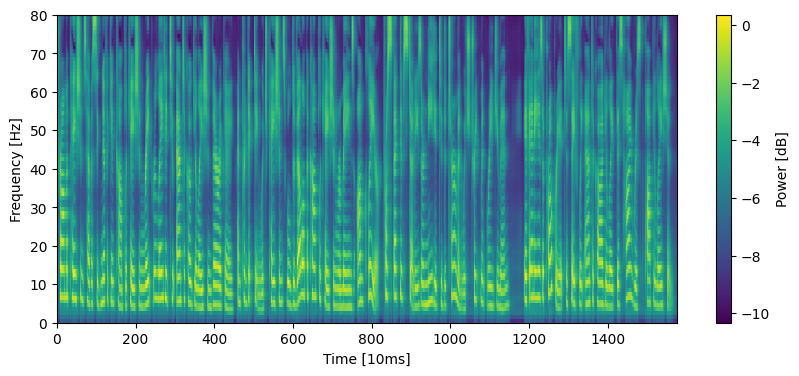

```python
# Plot MEL spectrogram created from text
plot_mel(mel)
```

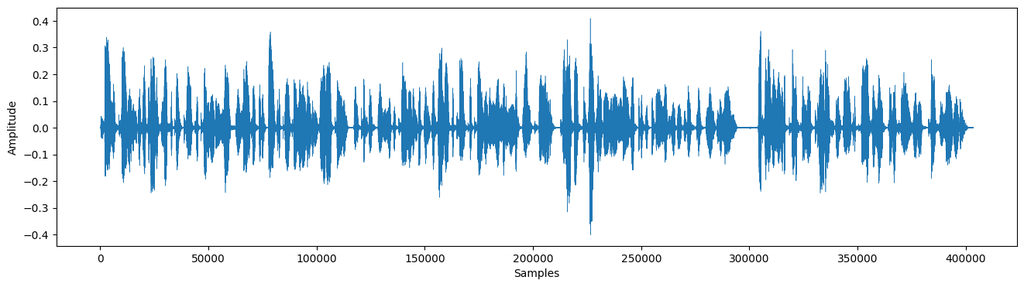

```python
# Plot synthetized audio
plot_audio(audio)
```